# Practical Machine Learning Assignment

#### Regression Analysis Tree

Now we fit a tree to these data, and summarize and plot it. First, we use the ‘tree’ package. It is much faster than ‘caret’ package.

```r
library(tree)
set.seed(12345)
tree.training=tree(classe~.,data=training)
summary(tree.training)
```

```
##
## Classification tree:
## tree(formula = classe ~ ., data = training)
## Variables actually used in tree construction:
##  [1] "pitch_forearm"     "magnet_belt_y"     "accel_forearm_z"
##  [4] "magnet_dumbbell_y" "roll_forearm"      "magnet_dumbbell_z"
##  [7] "pitch_belt"        "yaw_belt"          "accel_dumbbell_y"
## [10] "accel_forearm_x"   "accel_dumbbell_z"
## Number of terminal nodes:  22
## Residual mean deviance:  1.566 = 21480 / 13720
## Misclassification error rate: 0.3084 = 4237 / 13737
```

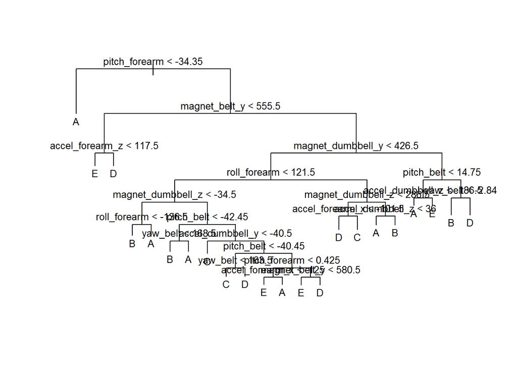

```r
plot(tree.training)
text(tree.training,pretty=0, cex =.8)
```

This is a dense tree which will have to be pruned

*Detailed Summary of Tree*

```r
tree.training
```

```
## node), split, n, deviance, yval, (yprob)
##       * denotes terminal node
##
##    1) root 13737 43620.00 A ( 0.284342 0.193492 0.174419 0.163937 0.183810 )
##      2) pitch_forearm < -34.35 1067    52.68 A ( 0.996251 0.003749 0.000000 0.000000 0.000000 ) *
##      3) pitch_forearm > -34.35 12670 40700.00 A ( 0.224388 0.209471 0.189108 0.177743 0.199290 )
##        6) magnet_belt_y < 555.5 1025  1039.00 E ( 0.001951 0.002927 0.000000 0.181463 0.813659 )
##         12) accel_forearm_z < 117.5 805    15.38 E ( 0.001242 0.000000 0.000000 0.000000 0.998758 ) *
##         13) accel_forearm_z > 117.5 220   218.60 D ( 0.004545 0.013636 0.000000 0.845455 0.136364 ) *
##        7) magnet_belt_y > 555.5 11645 37110.00 A ( 0.243967 0.227651 0.205754 0.177415 0.145213 )
##         14) magnet_dumbbell_y < 426.5 9571 29990.00 A ( 0.287744 0.179919 0.241250 0.169993 0.121095 )
##           28) roll_forearm < 121.5 6040 17810.00 A ( 0.409437 0.176987 0.185927 0.139073 0.088576 )
##             56) magnet_dumbbell_z < -34.5 1836  3330.00 A ( 0.685730 0.210240 0.003813 0.056645 0.043573 )
##              112) roll_forearm < -136.5 313   811.80 B ( 0.099042 0.431310 0.012780 0.303514 0.153355 ) *
##              113) roll_forearm > -136.5 1523  1811.00 A ( 0.806303 0.164806 0.001970 0.005909 0.021011 ) *
##             57) magnet_dumbbell_z > -34.5 4204 13050.00 A ( 0.288773 0.162464 0.265461 0.175071 0.108230 )
##              114) pitch_belt < -42.45 1005  2168.00 A ( 0.522388 0.354229 0.064677 0.047761 0.010945 )
##                228) yaw_belt < 168.5 463   915.40 B ( 0.140389 0.673866 0.140389 0.025918 0.019438 ) *
##                229) yaw_belt > 168.5 542   589.50 A ( 0.848708 0.081181 0.000000 0.066421 0.003690 ) *
##              115) pitch_belt > -42.45 3199  9815.00 C ( 0.215380 0.102219 0.328540 0.215067 0.138793 )
##                230) accel_dumbbell_y < -40.5 557   749.70 C ( 0.008977 0.030521 0.809695 0.025135 0.125673 ) *
##                231) accel_dumbbell_y > -40.5 2642  8260.00 A ( 0.258895 0.117335 0.227101 0.255110 0.141559 )
##                  462) pitch_belt < -40.45 853  1795.00 C ( 0.125440 0.008206 0.488863 0.370457 0.007034 )
##                    924) yaw_belt < 163.5 383   453.40 C ( 0.164491 0.013055 0.806789 0.000000 0.015666 ) *
##                    925) yaw_belt > 163.5 470   798.80 D ( 0.093617 0.004255 0.229787 0.672340 0.000000 ) *
##                  463) pitch_belt > -40.45 1789  5532.00 A ( 0.322527 0.169368 0.102292 0.200112 0.205702 )
##                    926) pitch_forearm < 0.425 513   893.40 A ( 0.641326 0.060429 0.013645 0.000000 0.284600 )
##                     1852) accel_forearm_x < -125 134    40.47 E ( 0.007463 0.000000 0.022388 0.000000 0.970149 ) *
##                     1853) accel_forearm_x > -125 379   387.70 A ( 0.865435 0.081794 0.010554 0.000000 0.042216 ) *
##                    927) pitch_forearm > 0.425 1276  4037.00 D ( 0.194357 0.213166 0.137931 0.280564 0.173981 )
##                     1854) magnet_belt_y < 580.5 612  1798.00 E ( 0.197712 0.263072 0.212418 0.031046 0.295752 ) *
##                     1855) magnet_belt_y > 580.5 664  1747.00 D ( 0.191265 0.167169 0.069277 0.510542 0.061747 ) *
##           29) roll_forearm > 121.5 3531 10740.00 C ( 0.079581 0.184933 0.335882 0.222883 0.176720 )
##             58) magnet_dumbbell_z < 286.5 2875  8028.00 C ( 0.029565 0.152000 0.408348 0.249739 0.160348 )
##              116) accel_forearm_x < -101.5 1009  2470.00 D ( 0.058474 0.059465 0.238850 0.551041 0.092170 ) *
##              117) accel_forearm_x > -101.5 1866  4708.00 C ( 0.013934 0.202036 0.500000 0.086817 0.197213 ) *
##             59) magnet_dumbbell_z > 286.5 656  1814.00 B ( 0.298780 0.329268 0.018293 0.105183 0.248476 )
##              118) accel_dumbbell_z < 36 231   330.90 A ( 0.809524 0.082251 0.047619 0.051948 0.008658 ) *
##              119) accel_dumbbell_z > 36 425   926.00 B ( 0.021176 0.463529 0.002353 0.134118 0.378824 ) *
##         15) magnet_dumbbell_y > 426.5 2074  5407.00 B ( 0.041948 0.447927 0.041948 0.211668 0.256509 )
##           30) pitch_belt < 14.75 1281  3066.00 B ( 0.067916 0.425449 0.067916 0.028884 0.409836 )
##             60) accel_dumbbell_z < -186.5 165   402.90 A ( 0.503030 0.266667 0.018182 0.157576 0.054545 ) *
##             61) accel_dumbbell_z > -186.5 1116  2180.00 E ( 0.003584 0.448925 0.075269 0.009857 0.462366 ) *
##           31) pitch_belt > 14.75 793  1169.00 D ( 0.000000 0.484237 0.000000 0.506936 0.008827 )
##             62) yaw_belt < -2.84 384     0.00 B ( 0.000000 1.000000 0.000000 0.000000 0.000000 ) *
##             63) yaw_belt > -2.84 409    70.83 D ( 0.000000 0.000000 0.000000 0.982885 0.017115 ) *
```

```r
library(caret)
modFit <- train(classe ~ .,method="rpart",data=training)
print(modFit$finalModel)
```

```
## n= 13737
##
## node), split, n, loss, yval, (yprob)
##       * denotes terminal node
##
##  1) root 13737 9831 A (0.28 0.19 0.17 0.16 0.18)
##    2) pitch_forearm< -33.35 1086   10 A (0.99 0.0092 0 0 0) *
##    3) pitch_forearm>=-33.35 12651 9821 A (0.22 0.21 0.19 0.18 0.2)
##      6) magnet_belt_y>=555.5 11626 8798 A (0.24 0.23 0.21 0.18 0.15)
##       12) magnet_dumbbell_y< 426.5 9553 6811 A (0.29 0.18 0.24 0.17 0.12)
##         24) roll_forearm< 121.5 6032 3566 A (0.41 0.18 0.19 0.14 0.089) *
##         25) roll_forearm>=121.5 3521 2335 C (0.078 0.18 0.34 0.22 0.18) *
##       13) magnet_dumbbell_y>=426.5 2073 1144 B (0.041 0.45 0.042 0.21 0.26)
##         26) total_accel_dumbbell>=5.5 1466  607 B (0.059 0.59 0.059 0.029 0.27) *
##         27) total_accel_dumbbell< 5.5 607  211 D (0 0.12 0.0016 0.65 0.23) *
##      7) magnet_belt_y< 555.5 1025  191 E (0.002 0.0029 0 0.18 0.81) *
```

*We can use rattle package to get a better looking plot*

```r
library(rattle)
```

[figure not shown]

```r
fancyRpartPlot(modFit$finalModel)
```

*The result from ‘caret’ ‘rpart’ package is close to ‘tree’ package.*

#### Cross Validation

```r
tree.pred=predict(tree.training,testing,type="class")
predMatrix = with(testing,table(tree.pred,classe))
sum(diag(predMatrix))/sum(as.vector(predMatrix)) # error rate
```

```
## [1] 0.6796941
```

```r
tree.pred=predict(modFit,testing)
predMatrix = with(testing,table(tree.pred,classe))
sum(diag(predMatrix))/sum(as.vector(predMatrix)) # error rate
```

```
## [1] 0.4995752
```

The 0.50 from ‘caret’ package is much lower than the result with training set.

#### Pruning tree

*The full depth tree is pruned as follows:*

```r
cv.training=cv.tree(tree.training,FUN=prune.misclass)
cv.training
```

```
## $size
##  [1] 22 21 20 19 17 16 15 12 10  7  5  1
##
## $dev
##  [1] 4278 4311 4468 4780 4866 5257 5342 6600 6600 6600 7271 9831
##
## $k
##  [1]     -Inf  54.0000 104.0000 129.0000 136.0000 156.0000 168.0000
##  [8] 200.6667 201.0000 203.0000 259.5000 644.7500
##
## $method
## [1] "misclass"
##
## attr(,"class")
## [1] "prune"         "tree.sequence"
```

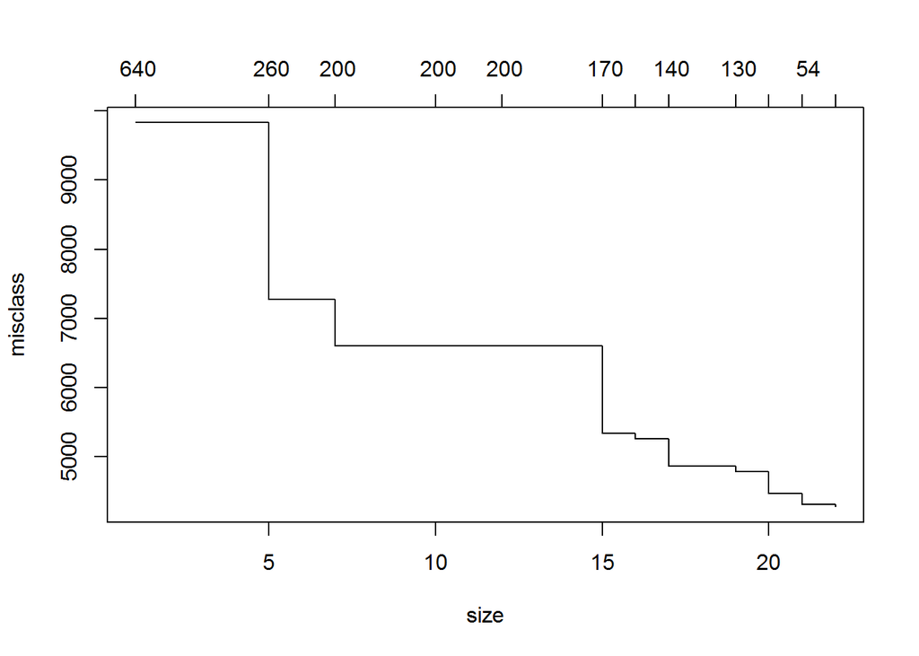

```r
plot(cv.training)
```

```r
prune.training=prune.misclass(tree.training,best=18)
#plot(prune.training);text(prune.training,pretty=0,cex =.8 )
```

The size of the tree goes down, the deviance goes up.The above expression prunes to size 18.The plot aboe indicates a size of 21 would be fine.

*Evaluate this pruned tree on the test data.*

```r
tree.pred=predict(prune.training,testing,type="class")
predMatrix = with(testing,table(tree.pred,classe))
sum(diag(predMatrix))/sum(as.vector(predMatrix)) # error rate
```

```
## [1] 0.6652506
```

#### Random Forests

Random Forests is used to fit more complex models.Random forests build lots of trees, and then average them to reduce the variance.

```r
require(randomForest)
set.seed(4567)
```

Lets fit a random forest and see how well it performs.

```r
rf.training=randomForest(classe~.,data=training,ntree=100, importance=TRUE)
rf.training
```

```
##
## Call:
##  randomForest(formula = classe ~ ., data = training, ntree = 100,      importance = TRUE)
##                Type of random forest: classification
##                      Number of trees: 100
## No. of variables tried at each split: 6
##
##         OOB estimate of  error rate: 0.84%
## Confusion matrix:
##      A    B    C    D    E class.error
## A 3898    7    0    0    1 0.002048131
## B   14 2632   10    1    1 0.009781791
## C    0   18 2370    8    0 0.010851419
## D    0    0   41 2207    4 0.019982238
## E    0    1    4    5 2515 0.003960396
```

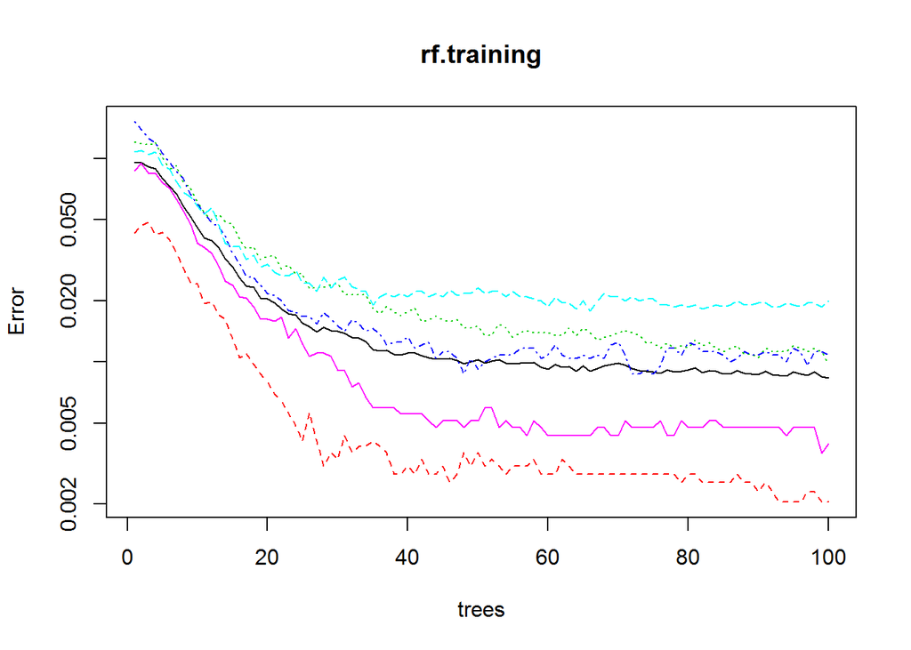

```r
plot(rf.training, log="y")
```

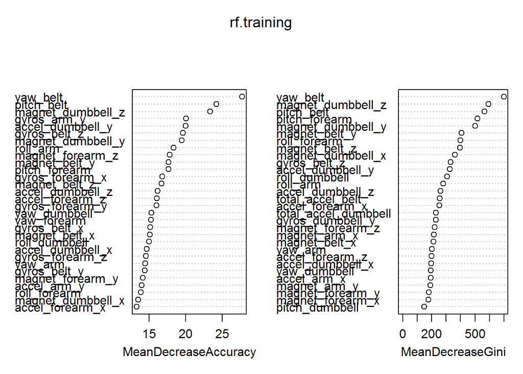

```r
varImpPlot(rf.training,)
```

```r
#rf.training1=randomForest(classe~., data=training, proximity=TRUE )
#DSplot(rf.training1, training$classe)
```

*Variables have higher impact on the prediction.*

Below is the Prediction for out-of sample accuracy on test data.

```r
tree.pred=predict(rf.training,testing,type="class")
predMatrix = with(testing,table(tree.pred,classe))
sum(diag(predMatrix))/sum(as.vector(predMatrix)) # error rate
```

```
## [1] 0.9938828
```

0.99 means we got a very accurate estimate.

Number of variables tried at each split: 6. This means every time we only randomly use 6 predictors to grow the tree to give a good fit.

### Conclusion

Prediction of the testing data from the website.

```r
answers <- predict(rf.training, testSet)
answers
```

```
##  1  2  3  4  5  6  7  8  9 10 11 12 13 14 15 16 17 18 19 20
##  B  A  B  A  A  E  D  B  A  A  B  C  B  A  E  E  A  B  B  B
## Levels: A B C D E
```

Those answers are going to submit to website for grading. It shows that this random forest model did a good job.